# Data Science Capstone Milestone Report

Yanyi Yuan

June 12, 2018

In this project, we performed exploratory analysis of the text data, to understand the distribution of words and relationship between the words.

## 1 Data Loading

```r
library(tm)
library(stylo)
# READ TEXT FILE
setwd("C:/Users/me/Documents/Coursera/capstone/Coursera-SwiftKey/final/en_US")
con1 <- file("en_Us.blogs.txt","r")
blogs<-readLines(con1)
close(con1)

con2 <- file("en_Us.news.txt","r")
news<-readLines(con2)
close(con2)

con3<- file("en_Us.twitter.txt","r")
twitter<-readLines(con3)
close(con3)
```

## 2 Summary Statistics of Data

2.1 Size of data file in MB:

```r
#Size of data
setwd("C:/Users/me/Documents/Coursera/capstone/Coursera-SwiftKey/final/en_US")
size_data_MB <- c(file.info("en_US.blogs.txt")$size,file.info("en_US.news.txt")$size,file.info("en_US.twitter.txt")$size)
size_data_MB<- data.frame(size_data_MB)
rownames(size_data_MB)<-c("blogs","news","twitter")
size_data_MB <- size_data_MB/1024^2  # size of file
size_data_MB
```

```
##         size_data_MB
## blogs       200.4242
## news        196.2775
## twitter     159.3641
```

2.2 Number of lines in each file:

```r
lines <- c(length(blogs),length(news),length(twitter))
lines <- data.frame(lines)
rownames(lines)<-c("blogs","news","twitter")
format(lines,big.mark = ",")  #Number of lines
```

```
##             lines
## blogs     899,288
## news       77,259
## twitter 2,360,148
```

2.3 Number of words in each file:

```r
library(stringi)
words_blogs <- stri_count_words(blogs)
words_news <- stri_count_words(news)
words_twitter <- stri_count_words(twitter)

words <- c(sum(words_blogs),sum(words_news),sum(words_twitter))
words <- data.frame(words)
rownames(words)<-c("blogs","news","twitter")
format(words,big.mark = ",")  #Number of words
```

```
##              words
## blogs   38,154,238
## news     2,693,898
## twitter 30,218,125
```

## 3 Data Sampling

Training dataset is sampled as 10 percent of the original dataset.

```r
blogsSample <- sample(blogs, length(blogs)*0.1)
newsSample <- sample(news, length(news)*0.1)
twitterSample <- sample(twitter, length(twitter)*0.1)
Sample <- c(blogsSample,newsSample,twitterSample)
```

## 4 Data Cleaning

Clean the training dataset by removing non ASCII characters, numbers, punctuations, stopwords and converting characters to lower case.

```r
#Remove non ASCII characters
Sample<- unlist(strsplit(Sample, split=" "))

Index<- grep("Sample", iconv(Sample, "latin1", "ASCII", sub="Sample"))
Sample<- Sample[ - Index]

Sample<- paste(Sample, collapse = " ")

#Convert Character to Corpus
Sample_corpus<- Corpus(VectorSource(Sample))

#Convert characters to lower case
Sample_corpus<- tm_map(Sample_corpus, tolower)

#Remove punctuation
Sample_corpus<- tm_map(Sample_corpus, removePunctuation)

#Remove numbers
Sample_corpus<- tm_map(Sample_corpus, removeNumbers)


#Remove stop words
Sample_corpus<- tm_map(Sample_corpus, removeWords, stopwords("english"))

#Remove white space
Sample_corpus <- tm_map(Sample_corpus, stripWhitespace)
```

## 5 Exploratory Data Analysis

We run analysis to find the most frequent unigram, bigram and trigram.

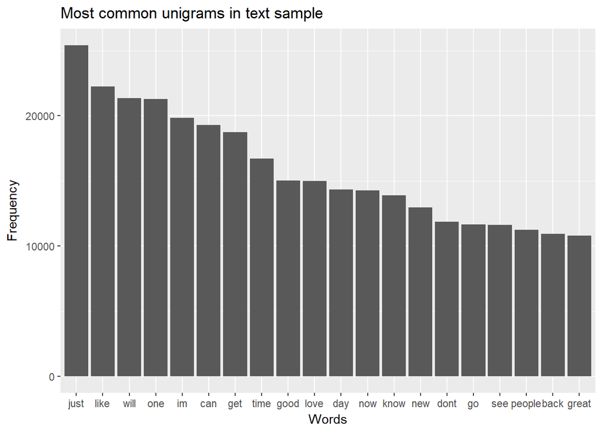

```r
#Count the freqency of one, two and three ngrams
Sample_txt <- Sample_corpus[[1]]$content
Sample_txt <- txt.to.words(Sample_txt)

Unigram<-data.frame(table(make.ngrams(Sample_txt, ngram.size = 1)))
Bigram<-data.frame(table(make.ngrams(Sample_txt, ngram.size = 2)))
Trigram<-data.frame(table(make.ngrams(Sample_txt, ngram.size = 3)))

#Order by the frequency of one, two and three ngrams

Unigram <- Unigram[order(Unigram$Freq,decreasing = TRUE),]
Bigram <- Bigram[order(Bigram$Freq,decreasing = TRUE),]
Trigram <- Trigram[order(Trigram$Freq,decreasing = TRUE),]

#plot frequency bar chart
library(ggplot2)
ggplot(Unigram[1:20,],aes(x=reorder(Unigram$Var1[1:20],-Unigram$Freq[1:20]),y=Unigram$Freq[1:20]))+geom_bar(stat="identity")+ labs(x="Words",y="Frequency", title="Most common unigrams in text sample")
```

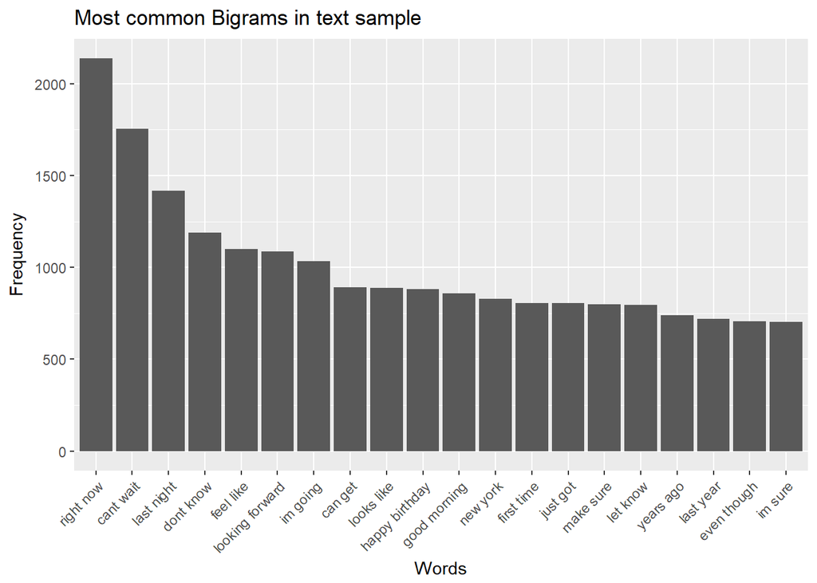

```r
ggplot(Bigram[1:20,],aes(x=reorder(Bigram$Var1[1:20],-Bigram$Freq[1:20]),y=Bigram$Freq[1:20]))+geom_bar(stat="identity")+ labs(x="Words",y="Frequency", title="Most common Bigrams in text sample")+theme(axis.text.x=element_text(angle=45,hjust=1))
```

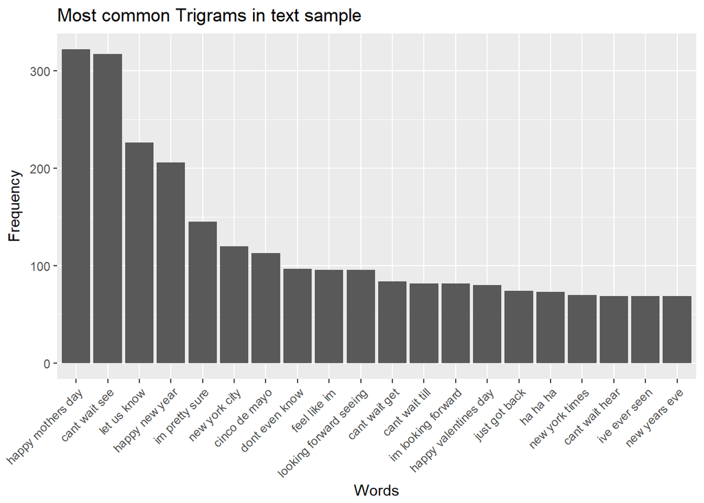

```r
ggplot(Trigram[1:20,],aes(x=reorder(Trigram$Var1[1:20],-Trigram$Freq[1:20]),y=Trigram$Freq[1:20]))+geom_bar(stat="identity")+ labs(x="Words",y="Frequency", title="Most common Trigrams in text sample")+theme(axis.text.x=element_text(angle=45,hjust=1))
```

## 6 Next Step

We will run the following tasks in the next steps: 1. Build basic n-gram model using the exploratory analysis performed. The n-gram model is used to predict the next word based on the previous 1, 2, or 3 words.

2. Build Katz’s back-off model to handle unseen n-grams. In some cases people will want to type a combination of words that does not appear in the corpora. Build Katz’s back-off model to handle cases where a particular n-gram isn’t observed.

Both model will be built using Shiny app.